# Homework 2 Quarto Notebook

Author

Taku Takahashi

# Homework 2: ggplot2 and Quarto practice

The goal of homework 2 is to give you hands-on practice with both (1) the ggplot2 package, which is one of the core tidyverse packages that R loads when you run library(tidyverse) in R and (2) Quarto document including rendering HTML files.

As stated in Lecture 2, it takes a while to really get used to the syntax of ggplot2.

The goal of this class is not to make you an expert in ggplot2 via memorization. However, you are expected to have a general understanding of ggplot2 scripts shared in class via Data312Exercise2.qmd and modify them accordingly to produce your desired visual output.

For example, in Lecture 2 via Data312Exercise2.qmd, you were taught that to create a scatter plot using the **penguins** data set using *two numeric variables* where we plotted **flipper_length_mm** on the x-axis and **body_mass_g** on the y-axis, you needed to run the following R script:

ggplot(data = **penguins**,

mapping = aes(x = **flipper_length_mm,** y = **body_mass_g**) ) +

geom_point()

Now, suppose you want to create another scatter plot using another data set. In this made up scenario, suppose you want to plot data from the *giraffe* data set with *neck_length* on the x-axis and *weight_lbs* on the y-axis, therefore, you need to be able to modify the previous code above and deduce that the script you need to run is the following:

ggplot(data = *giraffe*,

mapping = aes(x = *neck_length*, y = *weight_lbs*) ) +

geom_point()

## What you need to do for homework 2

You will be assigned tasks throughout this Quarto Document where you will need to fill in R code appropriately based on what was taught in:

1. Lecture 2 slides
   - Presentation version: https://jmtfeliciano.github.io/DATA312Spring2025/Data312Spring2025_Lecture2.html#1
   - Long format version: https://jmtfeliciano.github.io/DATA312Spring2025/Data312Spring2025_Lecture2Long
2. A filled out HTML version of the Data312Exercise.qmd file we worked on as a class: https://jmtfeliciano.github.io/DATA312Spring2025/Exercise2FilledOut

## Task 1 (1 pt)

Within the R chunk below, write and run scripts that will (1) load the tidyverse package and (2) load **diamonds**, a built-in data set from tidyverse, into your R environment.

```r
# Place your code under this comment and run the R chunk before going to the next task

library(tidyverse)
data("diamonds")
```

## Task 2 (1 pt)

Within the R chunk below, use head() or glimpse() to help you visualize a small sample of **diamonds**

```r
# Place your code under this comment and run the R chunk before going to the next task

head(diamonds)
```

```
# A tibble: 6 × 10
  carat cut       color clarity depth table price     x     y     z
  <dbl> <ord>     <ord> <ord>   <dbl> <dbl> <int> <dbl> <dbl> <dbl>
1  0.23 Ideal     E     SI2      61.5    55   326  3.95  3.98  2.43
2  0.21 Premium   E     SI1      59.8    61   326  3.89  3.84  2.31
3  0.23 Good      E     VS1      56.9    65   327  4.05  4.07  2.31
4  0.29 Premium   I     VS2      62.4    58   334  4.2   4.23  2.63
5  0.31 Good      J     SI2      63.3    58   335  4.34  4.35  2.75
6  0.24 Very Good J     VVS2     62.8    57   336  3.94  3.96  2.48
```

```r
glimpse(diamonds)
```

```
Rows: 53,940
Columns: 10
$ carat   <dbl> 0.23, 0.21, 0.23, 0.29, 0.31, 0.24, 0.24, 0.26, 0.22, 0.23, 0.…
$ cut     <ord> Ideal, Premium, Good, Premium, Good, Very Good, Very Good, Ver…
$ color   <ord> E, E, E, I, J, J, I, H, E, H, J, J, F, J, E, E, I, J, J, J, I,…
$ clarity <ord> SI2, SI1, VS1, VS2, SI2, VVS2, VVS1, SI1, VS2, VS1, SI1, VS1, …
$ depth   <dbl> 61.5, 59.8, 56.9, 62.4, 63.3, 62.8, 62.3, 61.9, 65.1, 59.4, 64…
$ table   <dbl> 55, 61, 65, 58, 58, 57, 57, 55, 61, 61, 55, 56, 61, 54, 62, 58…
$ price   <int> 326, 326, 327, 334, 335, 336, 336, 337, 337, 338, 339, 340, 34…
$ x       <dbl> 3.95, 3.89, 4.05, 4.20, 4.34, 3.94, 3.95, 4.07, 3.87, 4.00, 4.…
$ y       <dbl> 3.98, 3.84, 4.07, 4.23, 4.35, 3.96, 3.98, 4.11, 3.78, 4.05, 4.…
$ z       <dbl> 2.43, 2.31, 2.31, 2.63, 2.75, 2.48, 2.47, 2.53, 2.49, 2.39, 2.…
```

**Note:** If you want to quickly read the documentation for this data set, you may visit https://ggplot2.tidyverse.org/reference/diamonds.html or run **?diamonds** or **help(diamonds)** in your Console pane which should open and print the documentation directly into your Help pane.

## Task 3 (1 pt)

Using the **diamonds** data you loaded into your R environment, create a scatter plot using a ggplot2 method taught in class. More specifically, create a scatter plot with the *carat* variable (physical weight measurement of diamonds) on the x-axis and *price* on the y-axis (i.e., set x = carat, y = price). Include and run your script below:

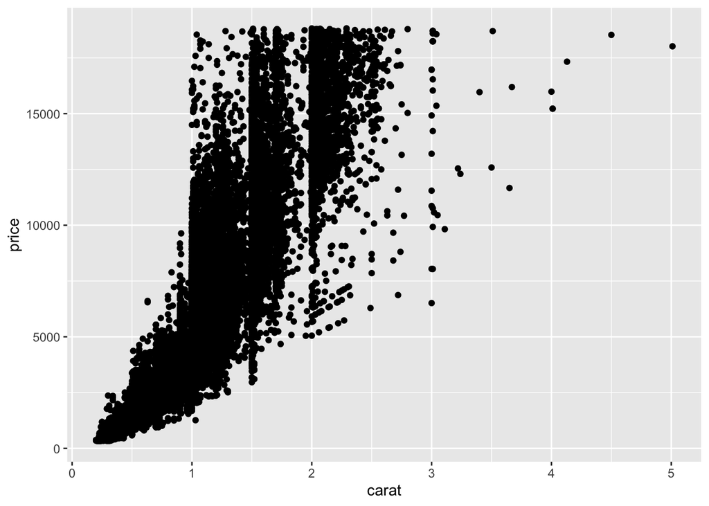

```r
# Place your code under this comment and run the R chunk before going to the next task

ggplot(data = diamonds) +
  geom_point(mapping = aes(x = carat, y = price))
```

## Task 4 (1 pt)

Pay closer visual attention to the scatter plot you created under Task 3. Provide an interpretation of your scatter plot. You may want to consider the following questions: what is the relationship between the two variables? Did it surprise you based on your real world knowledge or experience? Type in your interpretation below (preferably within 1-2 sentences but longer if you want to):

> (There is a positive linear relationship.The bigger the carat is, the higher the price gets. It’s not surpring to me.)

## Task 5 (1 pt)

Within the R chunk below, use the **diamonds** data set to create a bar plot showing the count of diamonds for each **cut** category (i.e., x = cut).

```r
# Place your code under this comment and run the R chunk before going to the next task

library(ggplot2)
glimpse(diamonds)
```

```
Rows: 53,940
Columns: 10
$ carat   <dbl> 0.23, 0.21, 0.23, 0.29, 0.31, 0.24, 0.24, 0.26, 0.22, 0.23, 0.…
$ cut     <ord> Ideal, Premium, Good, Premium, Good, Very Good, Very Good, Ver…
$ color   <ord> E, E, E, I, J, J, I, H, E, H, J, J, F, J, E, E, I, J, J, J, I,…
$ clarity <ord> SI2, SI1, VS1, VS2, SI2, VVS2, VVS1, SI1, VS2, VS1, SI1, VS1, …
$ depth   <dbl> 61.5, 59.8, 56.9, 62.4, 63.3, 62.8, 62.3, 61.9, 65.1, 59.4, 64…
$ table   <dbl> 55, 61, 65, 58, 58, 57, 57, 55, 61, 61, 55, 56, 61, 54, 62, 58…
$ price   <int> 326, 326, 327, 334, 335, 336, 336, 337, 337, 338, 339, 340, 34…
$ x       <dbl> 3.95, 3.89, 4.05, 4.20, 4.34, 3.94, 3.95, 4.07, 3.87, 4.00, 4.…
$ y       <dbl> 3.98, 3.84, 4.07, 4.23, 4.35, 3.96, 3.98, 4.11, 3.78, 4.05, 4.…
$ z       <dbl> 2.43, 2.31, 2.31, 2.63, 2.75, 2.48, 2.47, 2.53, 2.49, 2.39, 2.…
```

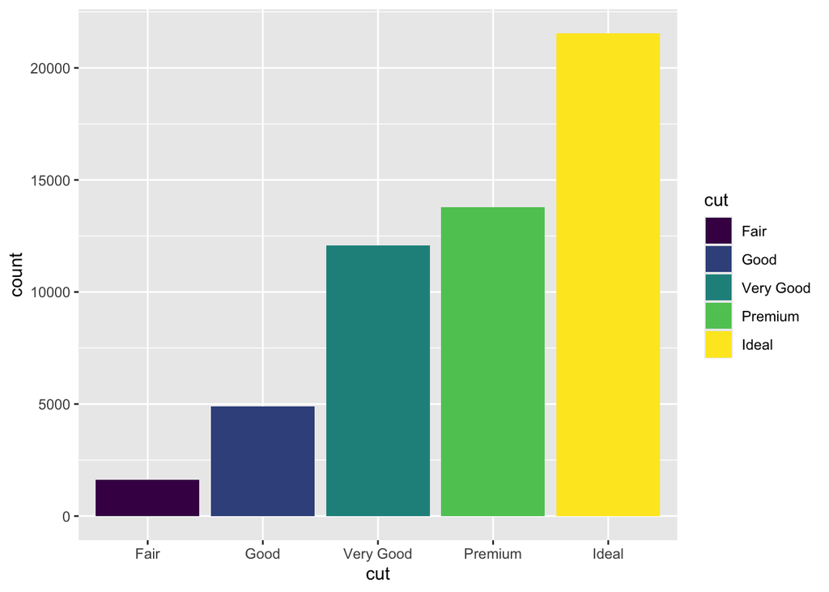

```r
ggplot(data = diamonds, aes(x = cut, fill = cut)) +
  geom_bar()
```

## Task 6 (1 pt)

**Within this single code chunk:** (1) load **mpg**, a built-in data set from tidyverse, into your R environment; and (2) print a small sample of your **mpg** data below using head() or glimpse().

```r
# Place your code under this comment and run the R chunk before going to the next task

data(mpg)

head(mpg)
```

```
# A tibble: 6 × 11
  manufacturer model displ  year   cyl trans      drv     cty   hwy fl    class
  <chr>        <chr> <dbl> <int> <int> <chr>      <chr> <int> <int> <chr> <chr>
1 audi         a4      1.8  1999     4 auto(l5)   f        18    29 p     compa…
2 audi         a4      1.8  1999     4 manual(m5) f        21    29 p     compa…
3 audi         a4      2    2008     4 manual(m6) f        20    31 p     compa…
4 audi         a4      2    2008     4 auto(av)   f        21    30 p     compa…
5 audi         a4      2.8  1999     6 auto(l5)   f        16    26 p     compa…
6 audi         a4      2.8  1999     6 manual(m5) f        18    26 p     compa…
```

```r
glimpse(mpg)
```

```
Rows: 234
Columns: 11
$ manufacturer <chr> "audi", "audi", "audi", "audi", "audi", "audi", "audi", "…
$ model        <chr> "a4", "a4", "a4", "a4", "a4", "a4", "a4", "a4 quattro", "…
$ displ        <dbl> 1.8, 1.8, 2.0, 2.0, 2.8, 2.8, 3.1, 1.8, 1.8, 2.0, 2.0, 2.…
$ year         <int> 1999, 1999, 2008, 2008, 1999, 1999, 2008, 1999, 1999, 200…
$ cyl          <int> 4, 4, 4, 4, 6, 6, 6, 4, 4, 4, 4, 6, 6, 6, 6, 6, 6, 8, 8, …
$ trans        <chr> "auto(l5)", "manual(m5)", "manual(m6)", "auto(av)", "auto…
$ drv          <chr> "f", "f", "f", "f", "f", "f", "f", "4", "4", "4", "4", "4…
$ cty          <int> 18, 21, 20, 21, 16, 18, 18, 18, 16, 20, 19, 15, 17, 17, 1…
$ hwy          <int> 29, 29, 31, 30, 26, 26, 27, 26, 25, 28, 27, 25, 25, 25, 2…
$ fl           <chr> "p", "p", "p", "p", "p", "p", "p", "p", "p", "p", "p", "p…
$ class        <chr> "compact", "compact", "compact", "compact", "compact", "c…
```

**Note:** If you want to quickly read the documentation for this data set, you may visit https://ggplot2.tidyverse.org/reference/mpg.html or run **?mpg** or **help(mpg)** in your Console pane which should open and print the documentation directly into your Help pane.

## Task 7 (1 pt)

Using the **mpg** data you loaded into your R environment, create a box plot using one of the ggplot2 techniques taught in lecture. More specifically, create a box plot to visualize the relationship between *class* (vehicle class such as minivan and compact) and *cty* (city mileage of the vehicle in miles).

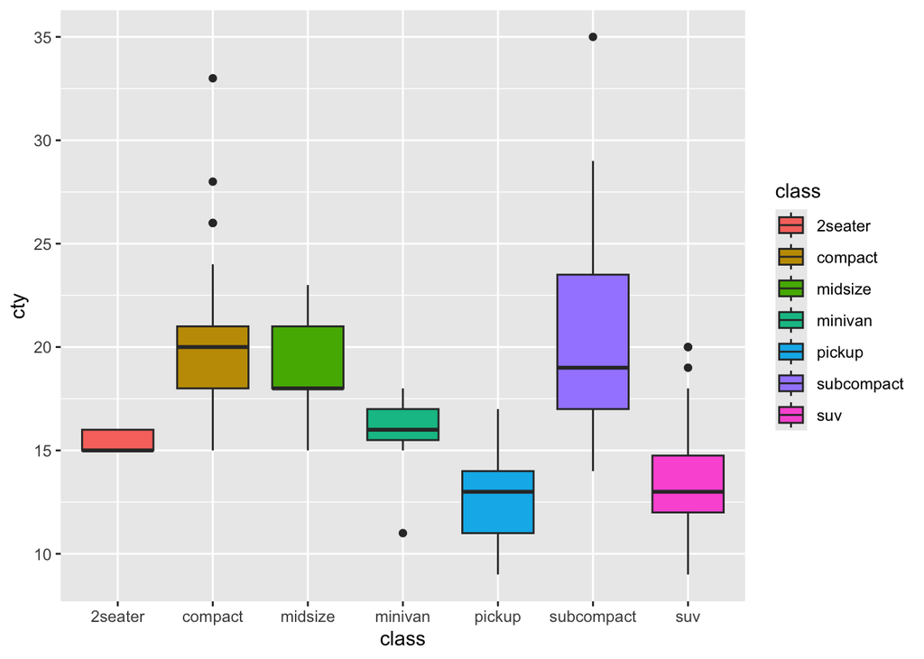

```r
# Place your code under this comment and run the R chunk before going to the next task

ggplot(data = mpg, aes (x=class, y=cty, fill = class)) +
  geom_boxplot()
```

## Task 8 (1 pt)

In reference to the visualization you created in Task 7: Which vehicle class has the highest median city mileage? If needed, please see lecture 2 slides on how to read the median from box plots. Provide your answer below:

> (Compact has the highest median)

## Task 9 (1 pt)

Using the **mpg** data you loaded into your R environment, create a box plot using one of the ggplot2 techniques taught in lecture. More specifically, create a box plot where the x-axis represents the highway miles per gallon of the vehicles and y-axis represents the vehicle manufacturer. For this problem, you will need to check the documentation by running ?mpg or help(mpg) in your console to see which variables you need to use. For this problem, you must also use labs() to ensure at the very least, the x-axis is labeled as “highway miles per gallon”

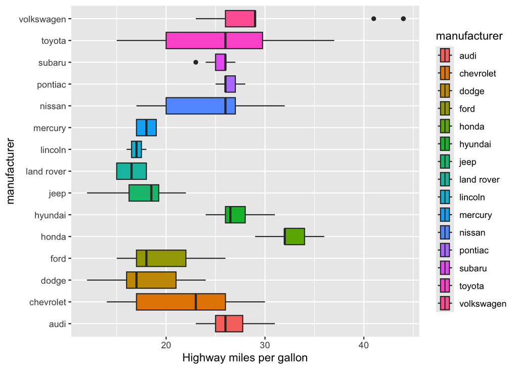

```r
# Place your code under this comment and run the R chunk before going to the next task

ggplot(data = mpg, aes(x = hwy, y = manufacturer,  fill = manufacturer)) +
  geom_boxplot() +
  labs(
    x = "Highway miles per gallon"
  )
```

## Task 10 (1 pt)

In class, we went over the general syntax of a ggplot code (see **Basic ggplot2 syntax** section in https://jmtfeliciano.github.io/DATA312Spring2025/Exercise2FilledOut )

Using this general syntax and experience you have gained with ggplot thus far, I want you create what is called a line plot using geom_line(). Although you were never taught geom_line() directly, you know what a typical ggplot code looks like to correctly place geom_line() where you’d expect it to be.

Within the R chunk below, do the following: (1) load **economics**, a built-in data set from tidyverse, into your R environment, (2) create a line plot using geom_line() where **x = date** and **y = unemploy**

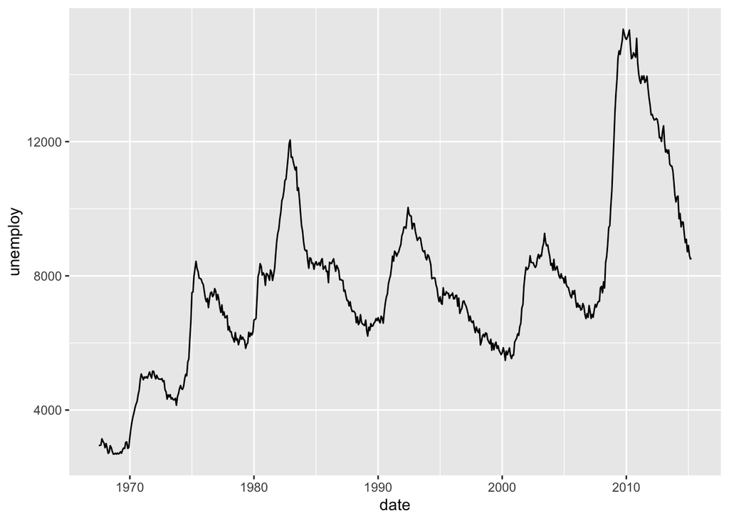

```r
# Place your code under this comment and run the R chunk before going to the next task

data("economics")

ggplot(data = economics, aes(x = date, y = unemploy)) +
  geom_line()
```

## **Final Task**

Once you complete Tasks 1-10, render an HTML file from this Quarto file. Please consult the lecture 2 slides as needed on how to render an HTML file from your Quarto document.

**Remember:** assuming all your R code are error free, the HTML file will be generated within the same folder where this Homework2.qmd document resides.

Please submit both your finalized .qmd and HTML files under Assignment 2 in Canvas.